# Project Draft

[figure not shown]

```r
plot_Google <- create_and_display_plot(pivot_Google, "Google")
print(plot_Google)
```

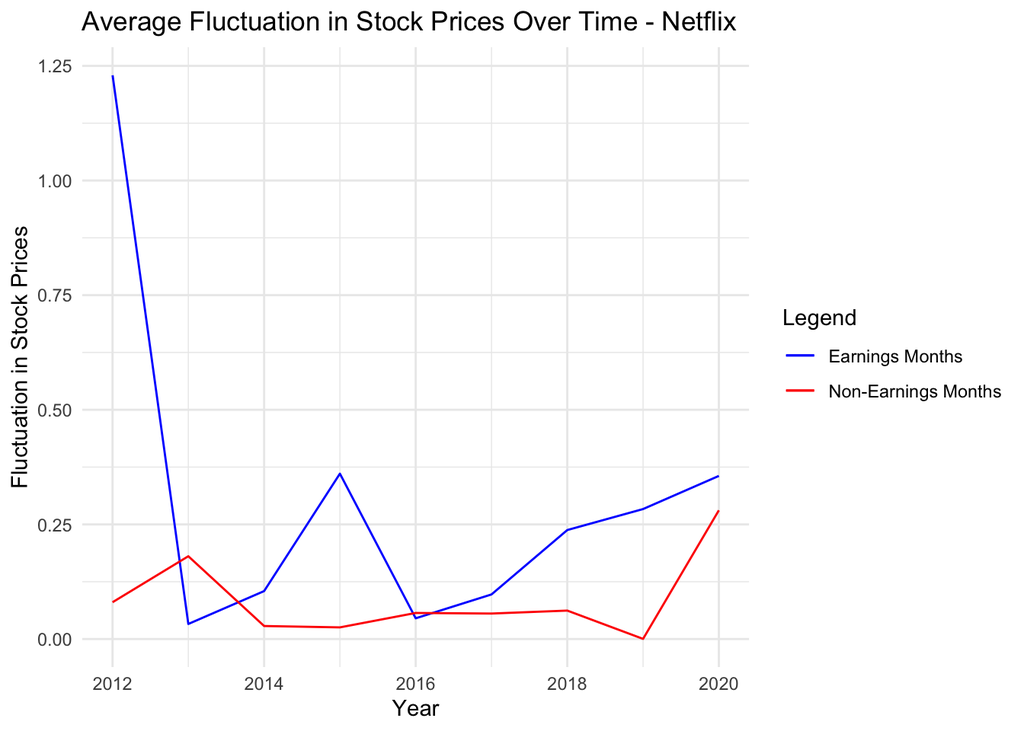

```r
plot_Netflix <- create_and_display_plot(pivot_Netflix, "Netflix")
print(plot_Netflix)
```

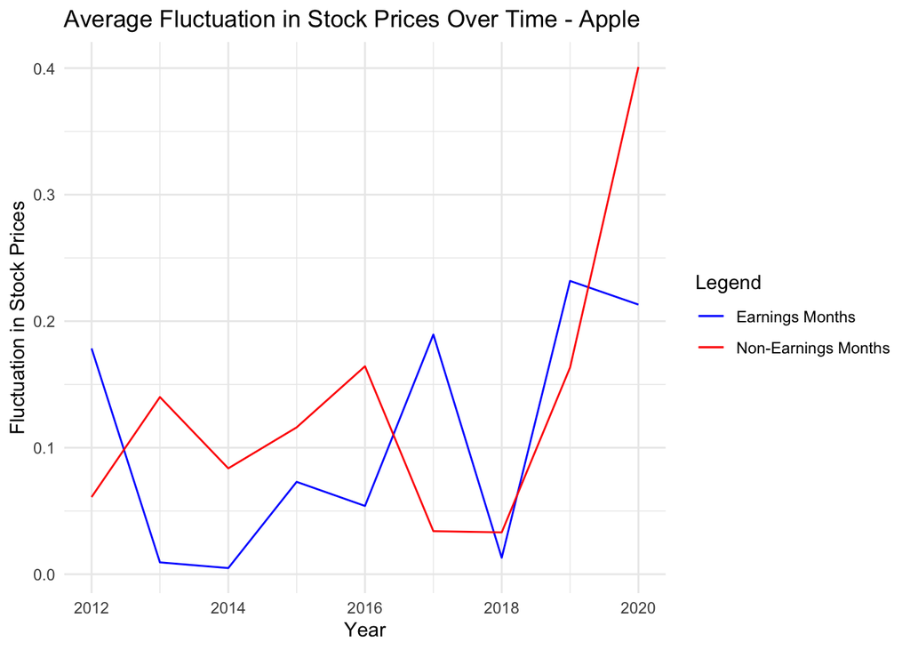

```r
plot_Apple <- create_and_display_plot(pivot_Apple, "Apple")
print(plot_Apple)
```

> The provided code generates line plots for the average fluctuation in stock prices over the years 2012 to 2020 for the five FAANG companies (Amazon, Facebook, Google, Netflix, and Apple). The average fluctuation is calculated separately for earnings months and non-earnings months, where earnings months typically include periods such as January, April, July, and October, and non-earnings months include months like February, March, May, and November.

> The purpose of these plots is to visually inspect and compare the trends in stock price fluctuation between earnings and non-earnings months for each FAANG company over the specified time period. By plotting these lines on the same graph, it allows for a direct visual comparison between the two types of months for each company.

### References

- Cite the source of your data.
  - https://www.kaggle.com/datasets/aayushmishra1512/faang-complete-stock-data
  - ** The information in the kaggle data set is from Yahoo Finance.
  - Collection Methodology: Web Scraping